# Assignment n.3

Polynomial regression and diagnostics

2025-03-13

### The *Boston* dataset

1. `crim` – per capita crime rate by town.
2. `zn` – proportion of residential land zoned for lots over 25,000 sq. ft.
3. `indus` – proportion of non-retain business acres per town.
4. `chas` - Charles River dummy variable (= 1 if tract bounds river; 0 otherwise).
5. `nox` – nitrogen oxides concentration (parts per million).
6. `rm` – average number of rooms per dwelling.
7. `age` – proportion of owner-occupied units built prior to 1940.
8. `dis` – weighted mean of distances to five Boston employment centers.
9. `rad` – index of accessibility to radial highways
10. `tax` – full-value property-tax rate per $10,000
11. `ptratio` – pupil-teacher ratio by town
12. `lstat` – lower status of the population (percent).
13. `medv` – median value of owner-occupied homes in $1000s.

Of these, medv is the response variable while the other 12 variables are possible predictors. The goal of this analysis is to fit a regression model that best explains the variation in `medv`.

## **We first consider the single predictor `lstat`**

##### 1. **Load the *Boston* data and plot `lstat` (x-axis) against `medv` (y-axis) using small green dots (that is the symbol encoded by the number 20). Then, fit a simple linear regression model, with `medv` as the response and `lstat` as the predictor, and use the function `summary()` to visualize the result. Finally, use the function `abline()` to add the regression line to the scatterplot.**

```r
library(ISLR2)
data(Boston)
plot(Boston$lstat, Boston$medv, pch=20, col="green")
lm.fit <- lm(medv ~ lstat, data=Boston)
summary(lm.fit)
```

```
##
## Call:
## lm(formula = medv ~ lstat, data = Boston)
##
## Residuals:
##     Min      1Q  Median      3Q     Max
## -15.168  -3.990  -1.318   2.034  24.500
##
## Coefficients:
##             Estimate Std. Error t value Pr(>|t|)
## (Intercept) 34.55384    0.56263   61.41   <2e-16 ***
## lstat       -0.95005    0.03873  -24.53   <2e-16 ***
## ---
## Signif. codes:  0 '***' 0.001 '**' 0.01 '*' 0.05 '.' 0.1 ' ' 1
##
## Residual standard error: 6.216 on 504 degrees of freedom
## Multiple R-squared:  0.5441, Adjusted R-squared:  0.5432
## F-statistic: 601.6 on 1 and 504 DF,  p-value: < 2.2e-16
```

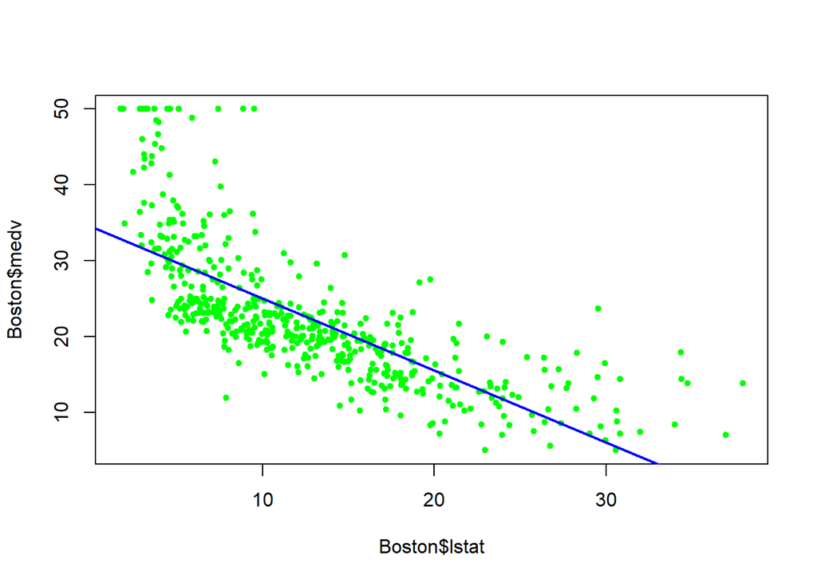

```r
abline(lm.fit, lwd=2, col="blue")
```

##### 2. **Plot again the previous scatterplot and use the function `lines()` to add the regression line (note that the functions `plot()` and `lines()` need to be in the same r-chunk).**

We first generate a sequence of x values.

```r
min.lstat <- min(Boston$lstat)
max.lstat <- max(Boston$lstat)
x.seq <- seq(min.lstat, max.lstat, length=100)
```

Then we generate the corresponding y values, and this can be done in two different ways: 1) explicitly, that is exploiting the equation of the fitted line, as follows

```r
beta0.hat <- coefficients(lm.fit)[1]
beta1.hat <- coefficients(lm.fit)[2]
y.seq <- beta0.hat+beta1.hat*x.seq
```

or, 2) using the function `predict()`

```r
x.new <- data.frame(lstat = x.seq)
y.seq <- predict(lm.fit, newdata = x.new)
```

finally we plot both the scatterplot and the line,

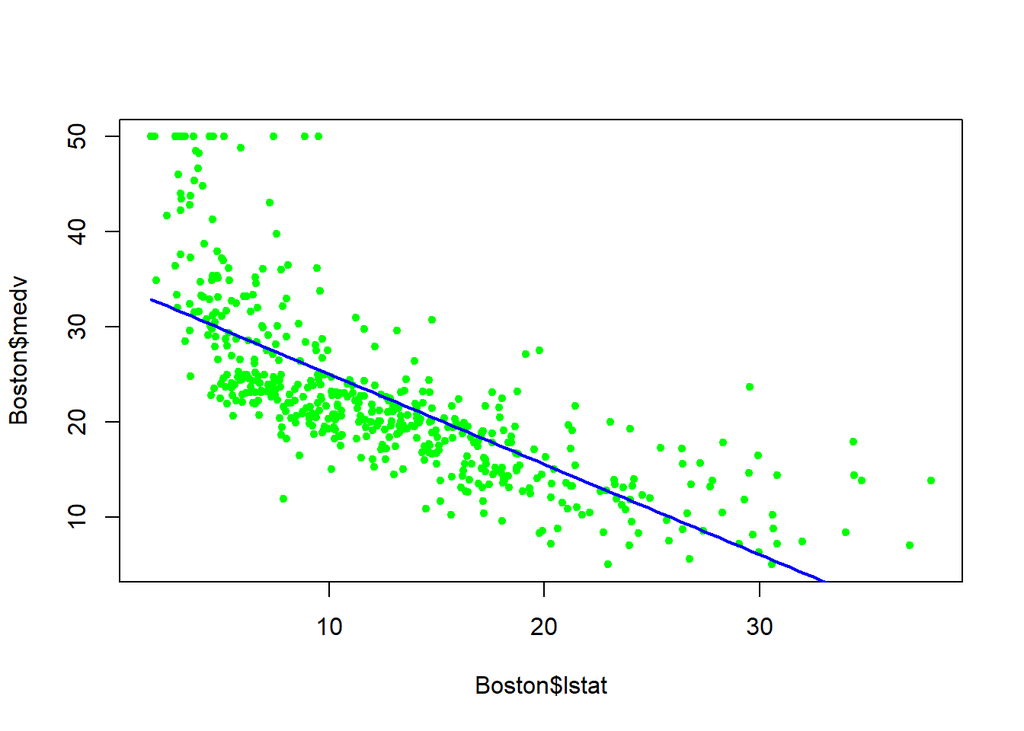

```r
plot(Boston$lstat, Boston$medv, pch=20, col="green")
lines(x.seq, y.seq, lwd=2, col="blue")
```

##### 3. **Obtain the vector of residuals and the vector fitted values and then use the plot the two vectors one against the other so at to produce a residual plot. Add to the plot a dotted horizontal line at x=0.**

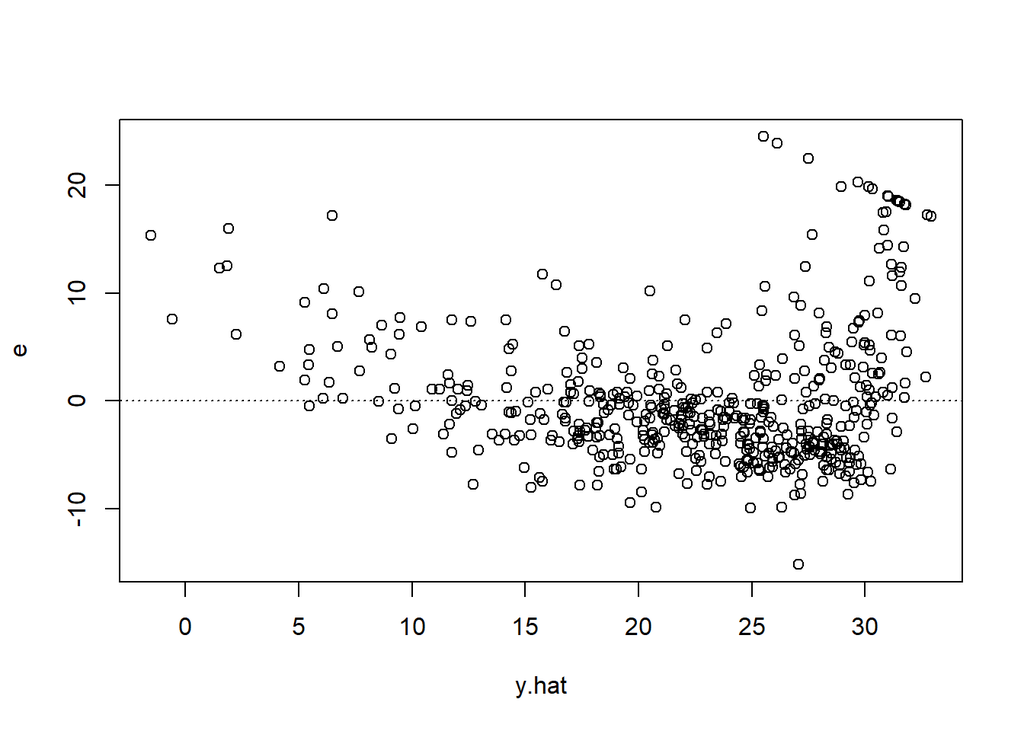

```r
e <- residuals(lm.fit)
y.hat <- fitted.values(lm.fit)
plot(y.hat, e)
abline(h=0, lty=3)
```

Recall that the same result can be obtained as

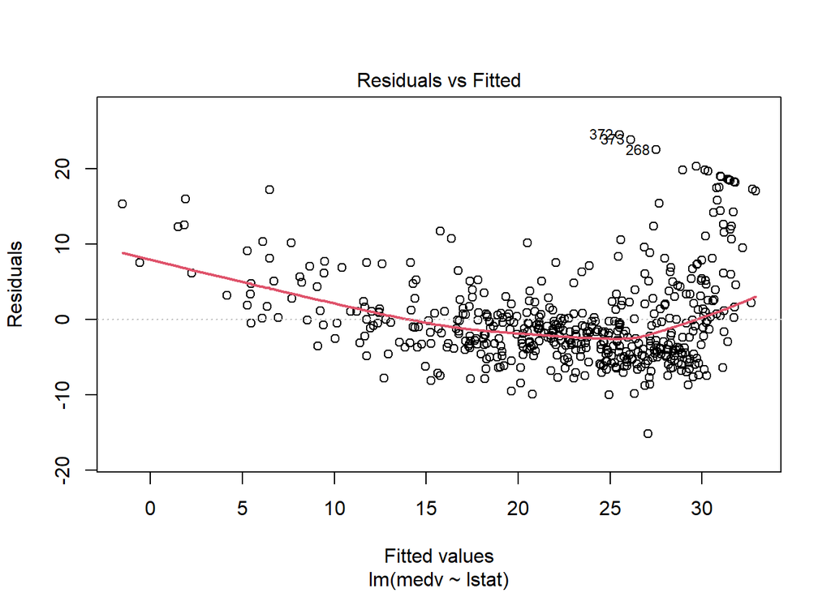

```r
plot(lm.fit, which=1, lwd=2)
```

##### 4. **Perform a quadratic regression of `medv` onto `lstat` and `lstat^2`. Fit the model, add the fitted curve to the scatterplot and then provide a residual plot.**

```r
lm.fit2 <- lm(medv ~ lstat + I(lstat^2), data=Boston)
summary(lm.fit2)
```

```
##
## Call:
## lm(formula = medv ~ lstat + I(lstat^2), data = Boston)
##
## Residuals:
##      Min       1Q   Median       3Q      Max
## -15.2834  -3.8313  -0.5295   2.3095  25.4148
##
## Coefficients:
##              Estimate Std. Error t value Pr(>|t|)
## (Intercept) 42.862007   0.872084   49.15   <2e-16 ***
## lstat       -2.332821   0.123803  -18.84   <2e-16 ***
## I(lstat^2)   0.043547   0.003745   11.63   <2e-16 ***
## ---
## Signif. codes:  0 '***' 0.001 '**' 0.01 '*' 0.05 '.' 0.1 ' ' 1
##
## Residual standard error: 5.524 on 503 degrees of freedom
## Multiple R-squared:  0.6407, Adjusted R-squared:  0.6393
## F-statistic: 448.5 on 2 and 503 DF,  p-value: < 2.2e-16
```

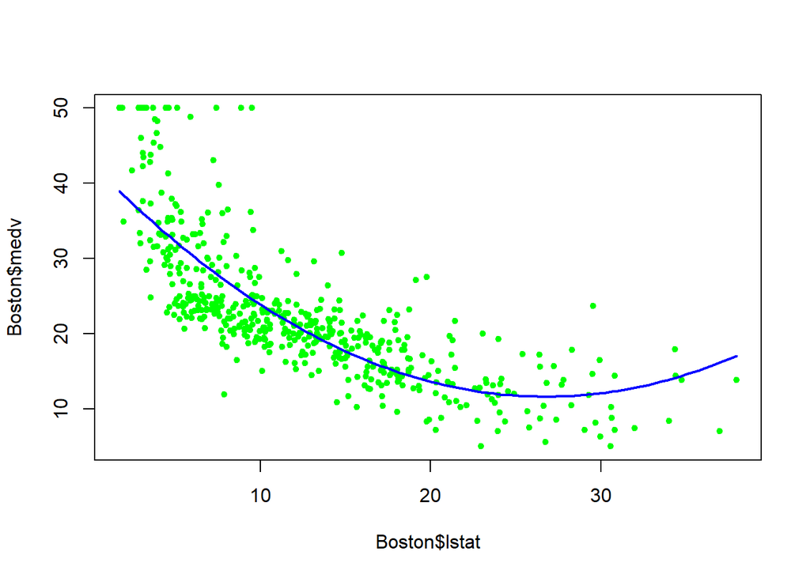

```r
y.seq <- predict(lm.fit2, newdata = x.new)
plot(Boston$lstat, Boston$medv, pch=20, col="green")
lines(x.seq, y.seq, lwd=2, col="blue")
```

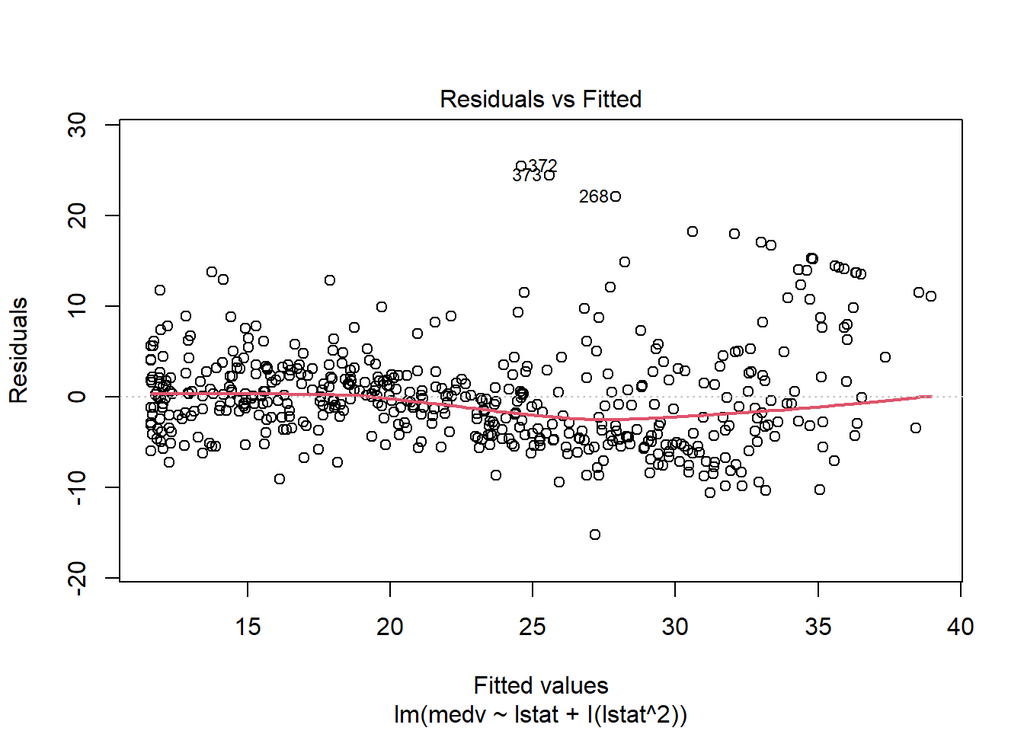

```r
plot(lm.fit2, which=1, lwd=2)
```

##### 5. **Perform a polynomial regression of degree 8 of `medv` onto `lstat` and, starting from this model, perform a stepwise backward elimination variable selection to remove all the variables with coefficient not significantly different to zero.**

```r
lm.fit8 <- lm(medv ~ poly(lstat, 8), data=Boston)
summary(lm.fit8)
```

```
##
## Call:
## lm(formula = medv ~ poly(lstat, 8), data = Boston)
##
## Residuals:
##      Min       1Q   Median       3Q      Max
## -13.7394  -3.1475  -0.7329   2.0959  26.9915
##
## Coefficients:
##                  Estimate Std. Error t value Pr(>|t|)
## (Intercept)       22.5328     0.2317  97.233  < 2e-16 ***
## poly(lstat, 8)1 -152.4595     5.2129 -29.247  < 2e-16 ***
## poly(lstat, 8)2   64.2272     5.2129  12.321  < 2e-16 ***
## poly(lstat, 8)3  -27.0511     5.2129  -5.189 3.08e-07 ***
## poly(lstat, 8)4   25.4517     5.2129   4.882 1.41e-06 ***
## poly(lstat, 8)5  -19.2524     5.2129  -3.693 0.000246 ***
## poly(lstat, 8)6    6.5088     5.2129   1.249 0.212404
## poly(lstat, 8)7    1.9416     5.2129   0.372 0.709703
## poly(lstat, 8)8   -6.7299     5.2129  -1.291 0.197302
## ---
## Signif. codes:  0 '***' 0.001 '**' 0.01 '*' 0.05 '.' 0.1 ' ' 1
##
## Residual standard error: 5.213 on 497 degrees of freedom
## Multiple R-squared:  0.6838, Adjusted R-squared:  0.6787
## F-statistic: 134.4 on 8 and 497 DF,  p-value: < 2.2e-16
```

```r
lm.fit7 <- lm(medv ~ poly(lstat, 7), data=Boston)
summary(lm.fit7)
```

```
##
## Call:
## lm(formula = medv ~ poly(lstat, 7), data = Boston)
##
## Residuals:
##      Min       1Q   Median       3Q      Max
## -14.3746  -3.1382  -0.7072   2.0646  26.9642
##
## Coefficients:
##                  Estimate Std. Error t value Pr(>|t|)
## (Intercept)       22.5328     0.2319  97.168  < 2e-16 ***
## poly(lstat, 7)1 -152.4595     5.2164 -29.227  < 2e-16 ***
## poly(lstat, 7)2   64.2272     5.2164  12.313  < 2e-16 ***
## poly(lstat, 7)3  -27.0511     5.2164  -5.186 3.13e-07 ***
## poly(lstat, 7)4   25.4517     5.2164   4.879 1.44e-06 ***
## poly(lstat, 7)5  -19.2524     5.2164  -3.691 0.000248 ***
## poly(lstat, 7)6    6.5088     5.2164   1.248 0.212708
## poly(lstat, 7)7    1.9416     5.2164   0.372 0.709888
## ---
## Signif. codes:  0 '***' 0.001 '**' 0.01 '*' 0.05 '.' 0.1 ' ' 1
##
## Residual standard error: 5.216 on 498 degrees of freedom
## Multiple R-squared:  0.6828, Adjusted R-squared:  0.6783
## F-statistic: 153.1 on 7 and 498 DF,  p-value: < 2.2e-16
```

```r
lm.fit6 <- lm(medv ~ poly(lstat, 6), data=Boston)
summary(lm.fit6)
```

```
##
## Call:
## lm(formula = medv ~ poly(lstat, 6), data = Boston)
##
## Residuals:
##      Min       1Q   Median       3Q      Max
## -14.7317  -3.1571  -0.6941   2.0756  26.8994
##
## Coefficients:
##                  Estimate Std. Error t value Pr(>|t|)
## (Intercept)       22.5328     0.2317  97.252  < 2e-16 ***
## poly(lstat, 6)1 -152.4595     5.2119 -29.252  < 2e-16 ***
## poly(lstat, 6)2   64.2272     5.2119  12.323  < 2e-16 ***
## poly(lstat, 6)3  -27.0511     5.2119  -5.190 3.06e-07 ***
## poly(lstat, 6)4   25.4517     5.2119   4.883 1.41e-06 ***
## poly(lstat, 6)5  -19.2524     5.2119  -3.694 0.000245 ***
## poly(lstat, 6)6    6.5088     5.2119   1.249 0.212313
## ---
## Signif. codes:  0 '***' 0.001 '**' 0.01 '*' 0.05 '.' 0.1 ' ' 1
##
## Residual standard error: 5.212 on 499 degrees of freedom
## Multiple R-squared:  0.6827, Adjusted R-squared:  0.6789
## F-statistic: 178.9 on 6 and 499 DF,  p-value: < 2.2e-16
```

```r
lm.fit5 <- lm(medv ~ poly(lstat, 5), data=Boston)
summary(lm.fit5)
```

```
##
## Call:
## lm(formula = medv ~ poly(lstat, 5), data = Boston)
##
## Residuals:
##      Min       1Q   Median       3Q      Max
## -13.5433  -3.1039  -0.7052   2.0844  27.1153
##
## Coefficients:
##                  Estimate Std. Error t value Pr(>|t|)
## (Intercept)       22.5328     0.2318  97.197  < 2e-16 ***
## poly(lstat, 5)1 -152.4595     5.2148 -29.236  < 2e-16 ***
## poly(lstat, 5)2   64.2272     5.2148  12.316  < 2e-16 ***
## poly(lstat, 5)3  -27.0511     5.2148  -5.187 3.10e-07 ***
## poly(lstat, 5)4   25.4517     5.2148   4.881 1.42e-06 ***
## poly(lstat, 5)5  -19.2524     5.2148  -3.692 0.000247 ***
## ---
## Signif. codes:  0 '***' 0.001 '**' 0.01 '*' 0.05 '.' 0.1 ' ' 1
##
## Residual standard error: 5.215 on 500 degrees of freedom
## Multiple R-squared:  0.6817, Adjusted R-squared:  0.6785
## F-statistic: 214.2 on 5 and 500 DF,  p-value: < 2.2e-16
```

##### 6. **Produce a plot of the model selected in the previous point and and then a residual plot.**

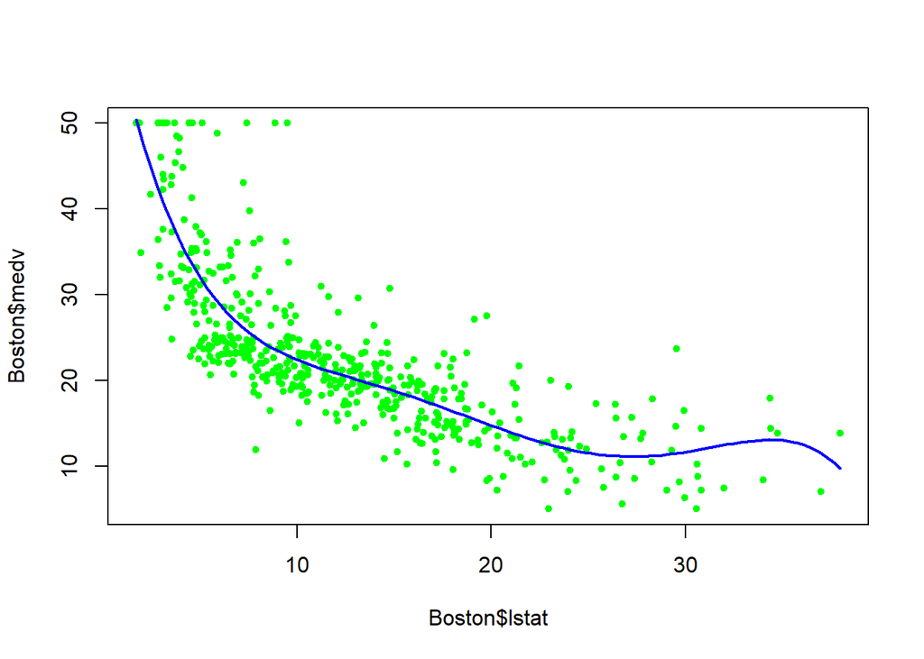

```r
y.seq <- predict(lm.fit5, newdata = x.new)
plot(Boston$lstat, Boston$medv, pch=20, col="green")
lines(x.seq, y.seq, lwd=2, col="blue")
```

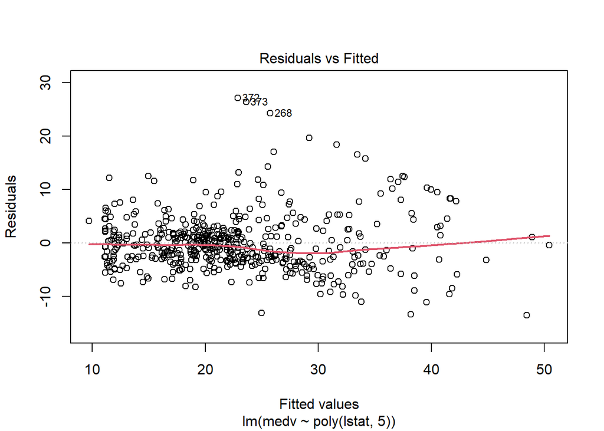

```r
plot(lm.fit5, which=1, lwd=2)
```

##### 7. **Perform a regression of the logarithm of `medv` onto `lstat` and `lstat^2`. Fit the model, add the fitted curve to the scatterplot and then provide a residual plot.**

```r
lm.fit.log <- lm(log(medv) ~ lstat + I(lstat^2), data=Boston)
summary(lm.fit.log)
```

```
##
## Call:
## lm(formula = log(medv) ~ lstat + I(lstat^2), data = Boston)
##
## Residuals:
##      Min       1Q   Median       3Q      Max
## -0.93717 -0.14675 -0.00854  0.13359  0.76992
##
## Coefficients:
##               Estimate Std. Error t value Pr(>|t|)
## (Intercept)  3.8296011  0.0365832 104.682  < 2e-16 ***
## lstat       -0.0813696  0.0051934 -15.668  < 2e-16 ***
## I(lstat^2)   0.0011113  0.0001571   7.074 5.08e-12 ***
## ---
## Signif. codes:  0 '***' 0.001 '**' 0.01 '*' 0.05 '.' 0.1 ' ' 1
##
## Residual standard error: 0.2317 on 503 degrees of freedom
## Multiple R-squared:  0.6799, Adjusted R-squared:  0.6786
## F-statistic: 534.2 on 2 and 503 DF,  p-value: < 2.2e-16
```

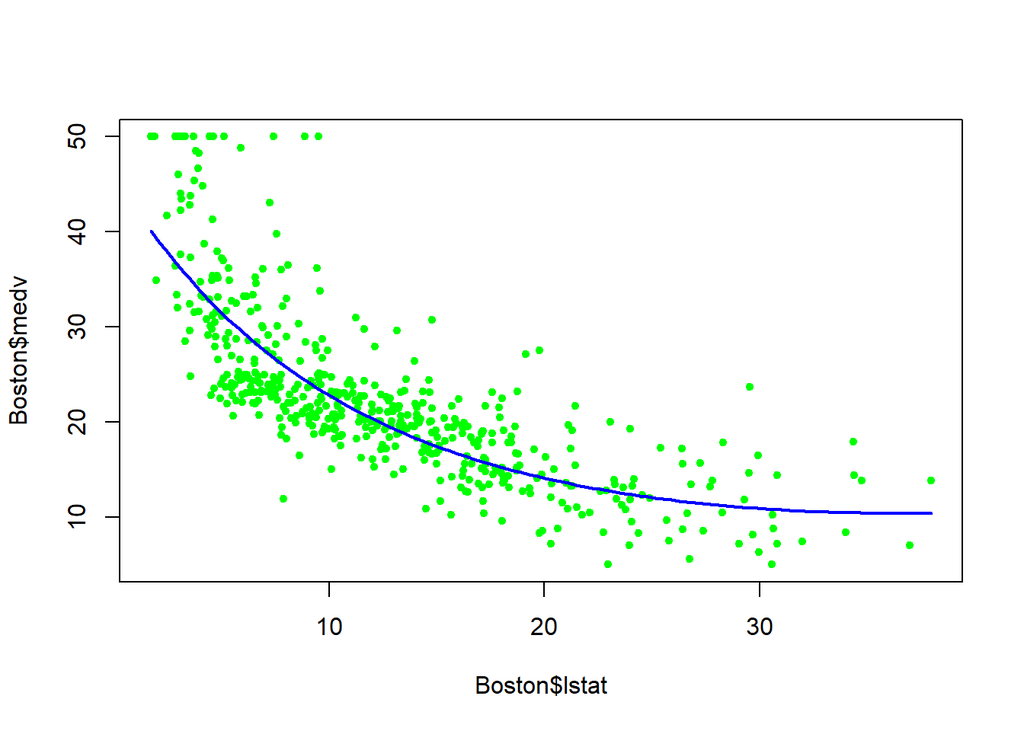

```r
plot(Boston$lstat, Boston$medv, pch=20, col="green")
y.seq <- predict(lm.fit.log, newdata = x.new)
plot(Boston$lstat, Boston$medv, pch=20, col="green")
lines(x.seq, exp(y.seq), lwd=2, col="blue")
```

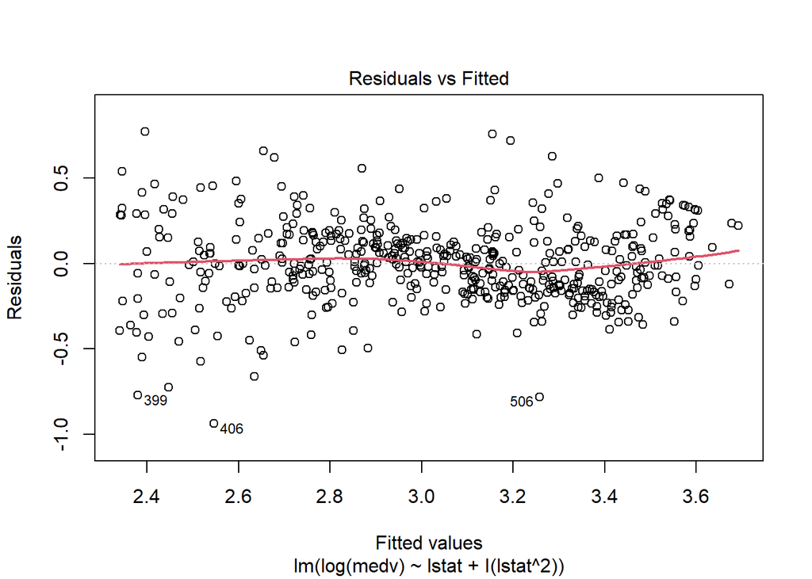

```r
plot(lm.fit.log, which=1, lwd=2)
```

##### 7. **Based on the last fitted model, produce a 95% confidence interval for the expected median value of a house for lstat=20.**

We can first obtain a confidence interval for the logarithm of median value,

```r
new.x <- data.frame(lstat=20)
log.y.hat <- predict(lm.fit.log, newdata = new.x, interval="confidence")
log.y.hat
```

```
##        fit      lwr      upr
## 1 2.646746 2.614639 2.678853
```

and then we apply the inverse transformation to obtain the required interval,

```r
y.hat <- exp(log.y.hat)
y.hat
```

```
##        fit      lwr      upr
## 1 14.10806 13.66229 14.56837
```

## **We now include in the analysis all the 12 predictors**

##### 1. **Define `chas` as a factor, obtain an overview of the summary statistics of the variables and a correlation matrix.**

The variable`chas` is binary, and by properly defining it as a factor implies, for example, that the function summary produces a table rather then the five-number-summary. Furthermore, the function cor() will produce an error if we try to compute the correlation for a factor.

```r
Boston$chas <- as.factor(Boston$chas)
summary(Boston)
```

```
##       crim                zn             indus       chas         nox
##  Min.   : 0.00632   Min.   :  0.00   Min.   : 0.46   0:471   Min.   :0.3850
##  1st Qu.: 0.08205   1st Qu.:  0.00   1st Qu.: 5.19   1: 35   1st Qu.:0.4490
##  Median : 0.25651   Median :  0.00   Median : 9.69           Median :0.5380
##  Mean   : 3.61352   Mean   : 11.36   Mean   :11.14           Mean   :0.5547
##  3rd Qu.: 3.67708   3rd Qu.: 12.50   3rd Qu.:18.10           3rd Qu.:0.6240
##  Max.   :88.97620   Max.   :100.00   Max.   :27.74           Max.   :0.8710
##        rm             age              dis              rad
##  Min.   :3.561   Min.   :  2.90   Min.   : 1.130   Min.   : 1.000
##  1st Qu.:5.886   1st Qu.: 45.02   1st Qu.: 2.100   1st Qu.: 4.000
##  Median :6.208   Median : 77.50   Median : 3.207   Median : 5.000
##  Mean   :6.285   Mean   : 68.57   Mean   : 3.795   Mean   : 9.549
##  3rd Qu.:6.623   3rd Qu.: 94.08   3rd Qu.: 5.188   3rd Qu.:24.000
##  Max.   :8.780   Max.   :100.00   Max.   :12.127   Max.   :24.000
##       tax           ptratio          lstat            medv
##  Min.   :187.0   Min.   :12.60   Min.   : 1.73   Min.   : 5.00
##  1st Qu.:279.0   1st Qu.:17.40   1st Qu.: 6.95   1st Qu.:17.02
##  Median :330.0   Median :19.05   Median :11.36   Median :21.20
##  Mean   :408.2   Mean   :18.46   Mean   :12.65   Mean   :22.53
##  3rd Qu.:666.0   3rd Qu.:20.20   3rd Qu.:16.95   3rd Qu.:25.00
##  Max.   :711.0   Max.   :22.00   Max.   :37.97   Max.   :50.00
```

```r
round(cor(Boston[, -4]), 2)
```

```
##          crim    zn indus   nox    rm   age   dis   rad   tax ptratio lstat
## crim     1.00 -0.20  0.41  0.42 -0.22  0.35 -0.38  0.63  0.58    0.29  0.46
## zn      -0.20  1.00 -0.53 -0.52  0.31 -0.57  0.66 -0.31 -0.31   -0.39 -0.41
## indus    0.41 -0.53  1.00  0.76 -0.39  0.64 -0.71  0.60  0.72    0.38  0.60
## nox      0.42 -0.52  0.76  1.00 -0.30  0.73 -0.77  0.61  0.67    0.19  0.59
## rm      -0.22  0.31 -0.39 -0.30  1.00 -0.24  0.21 -0.21 -0.29   -0.36 -0.61
## age      0.35 -0.57  0.64  0.73 -0.24  1.00 -0.75  0.46  0.51    0.26  0.60
## dis     -0.38  0.66 -0.71 -0.77  0.21 -0.75  1.00 -0.49 -0.53   -0.23 -0.50
## rad      0.63 -0.31  0.60  0.61 -0.21  0.46 -0.49  1.00  0.91    0.46  0.49
## tax      0.58 -0.31  0.72  0.67 -0.29  0.51 -0.53  0.91  1.00    0.46  0.54
## ptratio  0.29 -0.39  0.38  0.19 -0.36  0.26 -0.23  0.46  0.46    1.00  0.37
## lstat    0.46 -0.41  0.60  0.59 -0.61  0.60 -0.50  0.49  0.54    0.37  1.00
## medv    -0.39  0.36 -0.48 -0.43  0.70 -0.38  0.25 -0.38 -0.47   -0.51 -0.74
##          medv
## crim    -0.39
## zn       0.36
## indus   -0.48
## nox     -0.43
## rm       0.70
## age     -0.38
## dis      0.25
## rad     -0.38
## tax     -0.47
## ptratio -0.51
## lstat   -0.74
## medv     1.00
```

##### 2. **Fit the linear regression model of `medv` on all the remaining 12 variables and then remove the variable with largest variance inflation factor, if greater than 5. Repeat this operation iteratively until no variance inflation factor is greater than 5.**

```r
library(car)
lm.fit <- lm(medv ~ ., data=Boston)
vif(lm.fit)
```

```
##     crim       zn    indus     chas      nox       rm      age      dis
## 1.767486 2.298459 3.987181 1.071168 4.369093 1.912532 3.088232 3.954037
##      rad      tax  ptratio    lstat
## 7.445301 9.002158 1.797060 2.870777
```

```r
lm.fit <- lm(medv ~. -tax, data=Boston)
vif(lm.fit)
```

```
##     crim       zn    indus     chas      nox       rm      age      dis
## 1.767349 2.184172 3.217951 1.055023 4.343300 1.902642 3.085756 3.952445
##      rad  ptratio    lstat
## 2.772208 1.787049 2.870408
```

##### 3. **Apply the function `update()` to perform a stepwise backward elimination variable selection to remove all the variables with coefficient not significantly different to zero. Produce the residual plots of the selected model.**

```r
lm.fit <- lm(medv ~ .-tax, data=Boston)
summary(lm.fit)
```

```
##
## Call:
## lm(formula = medv ~ . - tax, data = Boston)
##
## Residuals:
##      Min       1Q   Median       3Q      Max
## -15.6847  -2.9592  -0.5854   1.8319  26.3693
##
## Coefficients:
##               Estimate Std. Error t value Pr(>|t|)
## (Intercept)  39.867312   4.958174   8.041 6.65e-15 ***
## crim         -0.120421   0.033336  -3.612 0.000334 ***
## zn            0.036637   0.013668   2.681 0.007595 **
## indus        -0.077606   0.056399  -1.376 0.169441
## chas1         3.196363   0.872236   3.665 0.000275 ***
## nox         -19.745344   3.879150  -5.090 5.10e-07 ***
## rm            3.758950   0.423435   8.877  < 2e-16 ***
## age           0.002351   0.013460   0.175 0.861397
## dis          -1.504251   0.203639  -7.387 6.45e-13 ***
## rad           0.112544   0.041244   2.729 0.006584 **
## ptratio      -0.970455   0.133183  -7.287 1.27e-12 ***
## lstat        -0.550104   0.051172 -10.750  < 2e-16 ***
## ---
## Signif. codes:  0 '***' 0.001 '**' 0.01 '*' 0.05 '.' 0.1 ' ' 1
##
## Residual standard error: 4.847 on 494 degrees of freedom
## Multiple R-squared:  0.7283, Adjusted R-squared:  0.7223
## F-statistic: 120.4 on 11 and 494 DF,  p-value: < 2.2e-16
```

```r
lm.fit.1 <- update(lm.fit, ~.-age)
summary(lm.fit.1)
```

```
##
## Call:
## lm(formula = medv ~ crim + zn + indus + chas + nox + rm + dis +
##     rad + ptratio + lstat, data = Boston)
##
## Residuals:
##      Min       1Q   Median       3Q      Max
## -15.7195  -2.9607  -0.5836   1.8199  26.4546
##
## Coefficients:
##              Estimate Std. Error t value Pr(>|t|)
## (Intercept)  39.80988    4.94242   8.055 5.99e-15 ***
## crim         -0.12045    0.03330  -3.617 0.000329 ***
## zn            0.03636    0.01356   2.681 0.007582 **
## indus        -0.07748    0.05634  -1.375 0.169675
## chas1         3.20416    0.87024   3.682 0.000257 ***
## nox         -19.56598    3.73712  -5.236 2.44e-07 ***
## rm            3.77376    0.41446   9.105  < 2e-16 ***
## dis          -1.51467    0.19451  -7.787 4.05e-14 ***
## rad           0.11186    0.04101   2.727 0.006614 **
## ptratio      -0.96853    0.13259  -7.304 1.12e-12 ***
## lstat        -0.54710    0.04815 -11.362  < 2e-16 ***
## ---
## Signif. codes:  0 '***' 0.001 '**' 0.01 '*' 0.05 '.' 0.1 ' ' 1
##
## Residual standard error: 4.842 on 495 degrees of freedom
## Multiple R-squared:  0.7283, Adjusted R-squared:  0.7228
## F-statistic: 132.7 on 10 and 495 DF,  p-value: < 2.2e-16
```

```r
lm.fit.2 <- update(lm.fit.1, ~.-indus)
summary(lm.fit.2)
```

```
##
## Call:
## lm(formula = medv ~ crim + zn + chas + nox + rm + dis + rad +
##     ptratio + lstat, data = Boston)
##
## Residuals:
##      Min       1Q   Median       3Q      Max
## -15.8550  -2.9880  -0.5477   1.8770  26.4105
##
## Coefficients:
##              Estimate Std. Error t value Pr(>|t|)
## (Intercept)  39.98405    4.94523   8.085 4.78e-15 ***
## crim         -0.11854    0.03330  -3.559 0.000407 ***
## zn            0.03658    0.01357   2.695 0.007279 **
## chas1         3.13944    0.86975   3.610 0.000338 ***
## nox         -21.37566    3.50093  -6.106 2.07e-09 ***
## rm            3.85056    0.41105   9.368  < 2e-16 ***
## dis          -1.45079    0.18905  -7.674 8.92e-14 ***
## rad           0.10457    0.04071   2.569 0.010495 *
## ptratio      -1.00175    0.13049  -7.677 8.74e-14 ***
## lstat        -0.55346    0.04797 -11.537  < 2e-16 ***
## ---
## Signif. codes:  0 '***' 0.001 '**' 0.01 '*' 0.05 '.' 0.1 ' ' 1
##
## Residual standard error: 4.847 on 496 degrees of freedom
## Multiple R-squared:  0.7273, Adjusted R-squared:  0.7223
## F-statistic: 146.9 on 9 and 496 DF,  p-value: < 2.2e-16
```

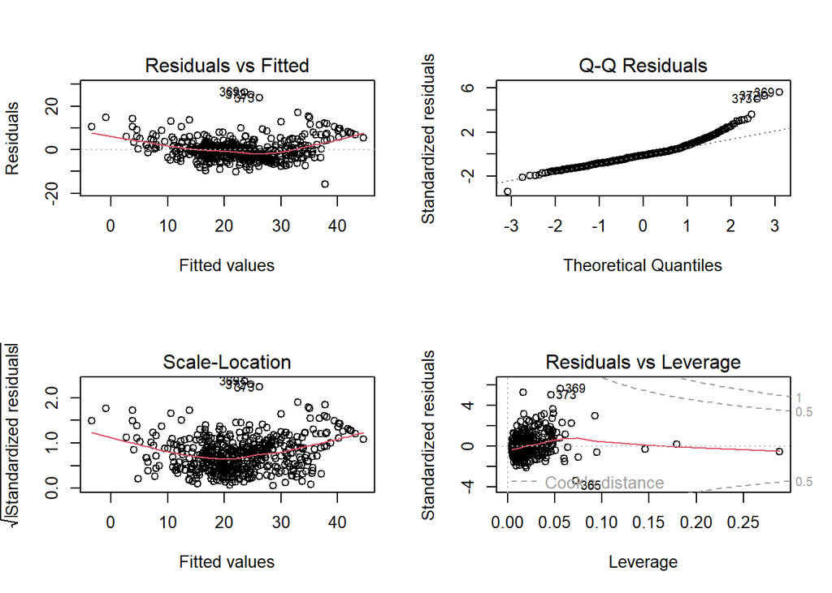

```r
par(mfrow=c(2,2))
plot(lm.fit.2)
```

```r
par(mfrow=c(1,1))
```

##### 4. **Produce a pairs-plot with the variables included in the selected model and try to identify the variables that have a nonlinear relationship with the response.**

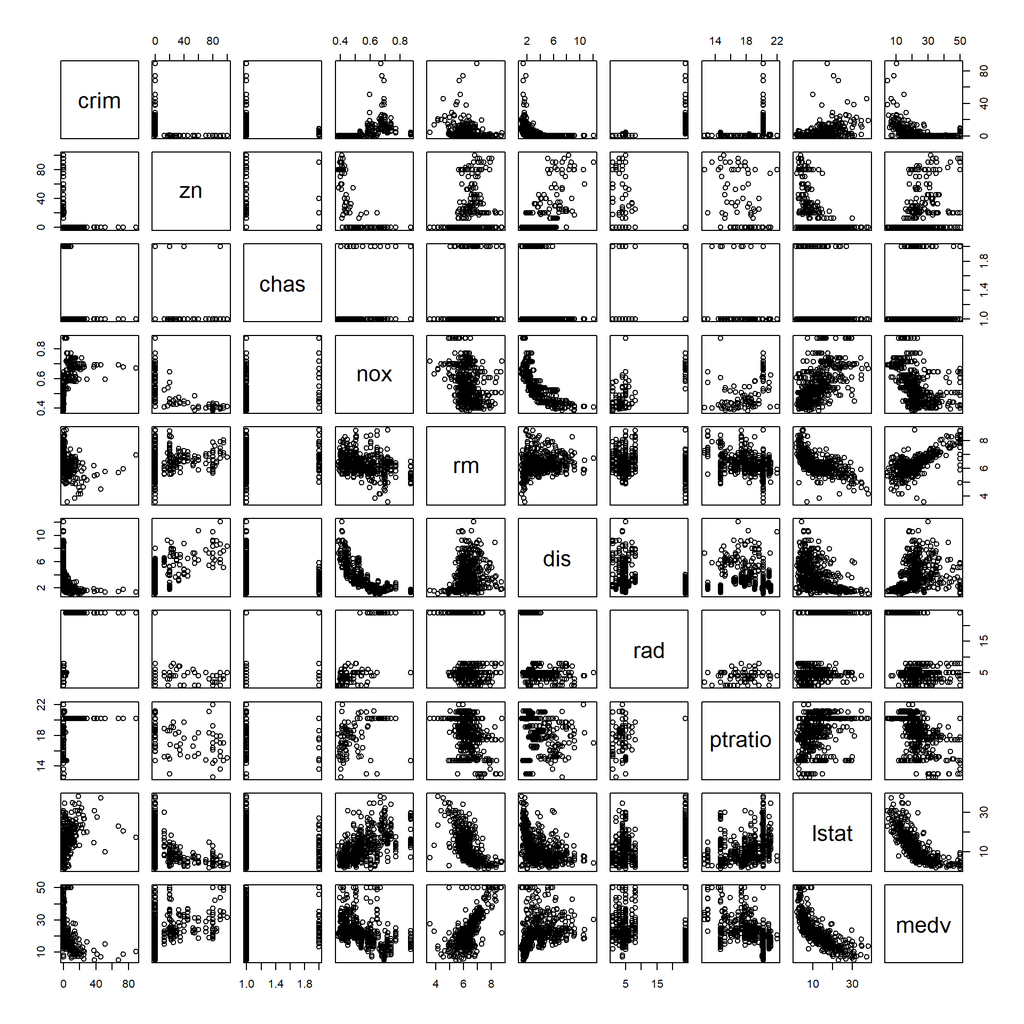

```r
pairs(Boston[, -c(3,7,10)])
```

We then highlight the scatterplots of the variables which appear to have a non linear relationship with the response.

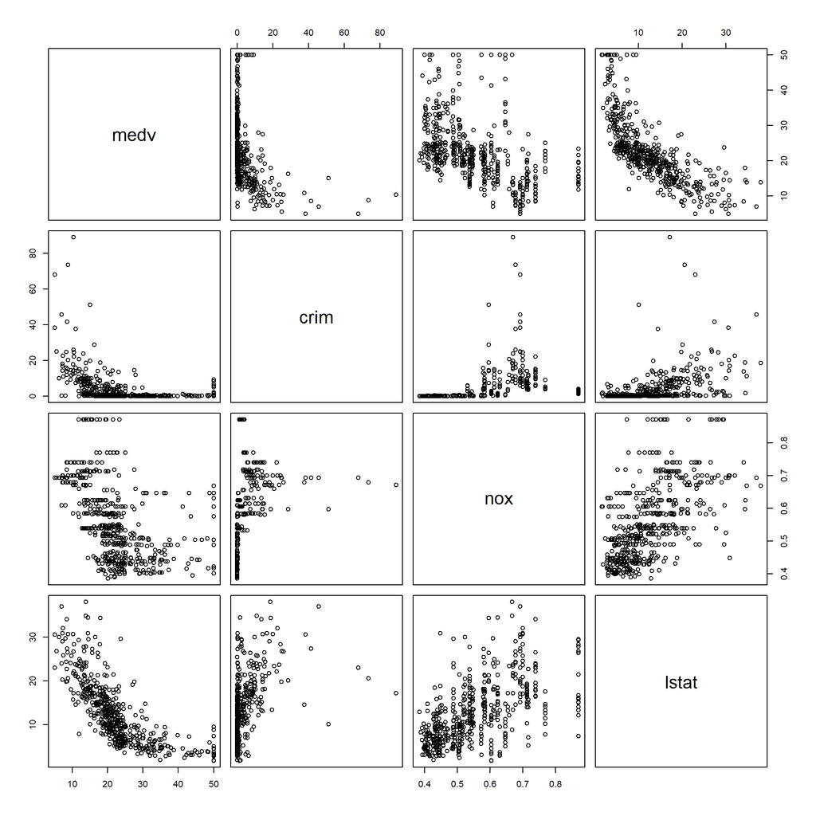

```r
pairs(Boston[, c("medv", "crim", "nox", "lstat")])
```

##### 5. **Include in the model a quadratic component for `crim` and `lstat` and check the residual plots.**

```r
lm.fit.3 <- update(lm.fit.2, ~. +I(lstat^2)+I(crim^2))
summary(lm.fit.3)
```

```
##
## Call:
## lm(formula = medv ~ crim + zn + chas + nox + rm + dis + rad +
##     ptratio + lstat + I(lstat^2) + I(crim^2), data = Boston)
##
## Residuals:
##      Min       1Q   Median       3Q      Max
## -18.2151  -2.7131  -0.3019   2.0951  25.4303
##
## Coefficients:
##               Estimate Std. Error t value Pr(>|t|)
## (Intercept)  46.519011   4.502613  10.332  < 2e-16 ***
## crim         -0.352675   0.089889  -3.923 9.97e-05 ***
## zn            0.014868   0.012455   1.194 0.233154
## chas1         2.822697   0.785118   3.595 0.000357 ***
## nox         -16.758945   3.184321  -5.263 2.12e-07 ***
## rm            3.151971   0.376734   8.367 6.12e-16 ***
## dis          -1.361036   0.171629  -7.930 1.47e-14 ***
## rad           0.177257   0.046423   3.818 0.000151 ***
## ptratio      -0.838875   0.118746  -7.064 5.51e-12 ***
## lstat        -1.777429   0.121117 -14.675  < 2e-16 ***
## I(lstat^2)    0.036121   0.003334  10.833  < 2e-16 ***
## I(crim^2)     0.002694   0.001181   2.280 0.023025 *
## ---
## Signif. codes:  0 '***' 0.001 '**' 0.01 '*' 0.05 '.' 0.1 ' ' 1
##
## Residual standard error: 4.365 on 494 degrees of freedom
## Multiple R-squared:  0.7796, Adjusted R-squared:  0.7747
## F-statistic: 158.9 on 11 and 494 DF,  p-value: < 2.2e-16
```

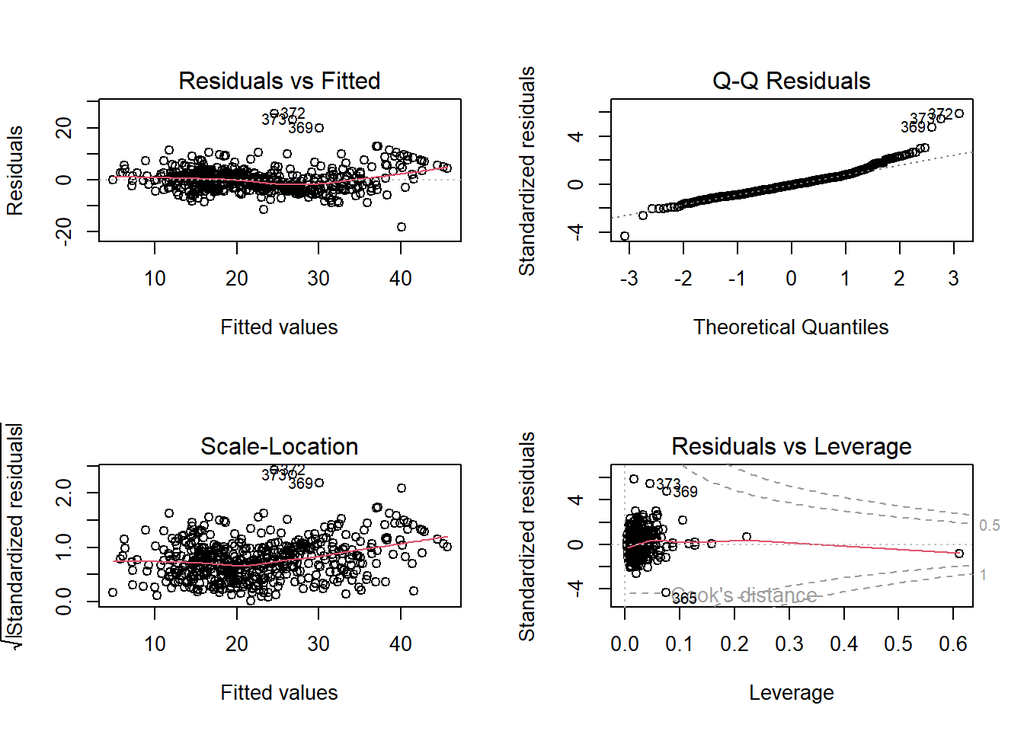

```r
par(mfrow=c(2,2))
plot(lm.fit.3)
```

```r
par(mfrow=c(1,1))
```

Although the scale-location plot is still not fully satisfying, the introduction of the quadratic component leads to a better fit and substantially improves both the R-squared and the adjusted R-squared statistics.

We fit again the resulting model so as to recall all the components of the model.

```r
lm.fit <- lm(medv ~ .-tax-age-indus+I(lstat^2)+I(crim^2), data=Boston)
summary(lm.fit)
```

```
##
## Call:
## lm(formula = medv ~ . - tax - age - indus + I(lstat^2) + I(crim^2),
##     data = Boston)
##
## Residuals:
##      Min       1Q   Median       3Q      Max
## -18.2151  -2.7131  -0.3019   2.0951  25.4303
##
## Coefficients:
##               Estimate Std. Error t value Pr(>|t|)
## (Intercept)  46.519011   4.502613  10.332  < 2e-16 ***
## crim         -0.352675   0.089889  -3.923 9.97e-05 ***
## zn            0.014868   0.012455   1.194 0.233154
## chas1         2.822697   0.785118   3.595 0.000357 ***
## nox         -16.758945   3.184321  -5.263 2.12e-07 ***
## rm            3.151971   0.376734   8.367 6.12e-16 ***
## dis          -1.361036   0.171629  -7.930 1.47e-14 ***
## rad           0.177257   0.046423   3.818 0.000151 ***
## ptratio      -0.838875   0.118746  -7.064 5.51e-12 ***
## lstat        -1.777429   0.121117 -14.675  < 2e-16 ***
## I(lstat^2)    0.036121   0.003334  10.833  < 2e-16 ***
## I(crim^2)     0.002694   0.001181   2.280 0.023025 *
## ---
## Signif. codes:  0 '***' 0.001 '**' 0.01 '*' 0.05 '.' 0.1 ' ' 1
##
## Residual standard error: 4.365 on 494 degrees of freedom
## Multiple R-squared:  0.7796, Adjusted R-squared:  0.7747
## F-statistic: 158.9 on 11 and 494 DF,  p-value: < 2.2e-16
```

##### 6. **Compute both the leverage statistics and the standardized residuals (this can be done with the functions `hatvalues()` and `rstandard()`, respectively). Remove the data points with either leverage value greater than 4 times the average leverege or absolute standardized residual larger than 3.5. Fit the selected model to the reduced dataset.**

We first obtain the sample size and the number of paramters of the selected model.

```r
dim(Boston)
```

```
## [1] 506  13
```

```r
n <- dim(Boston)[1]
n
```

```
## [1] 506
```

```r
p.plus.1 <- length(coefficients(lm.fit))
p.plus.1
```

```
## [1] 12
```

We then compute the threshold leverage and identify the row-indexes of the data points with leverage value above the threshold.

```r
thr <- p.plus.1/n*4
thr
```

```
## [1] 0.09486166
```

```r
lev.stat <- hatvalues(lm.fit)
i.lev <- which(lev.stat>thr)
i.lev
```

```
## 366 375 381 406 411 415 419
## 366 375 381 406 411 415 419
```

Next we compute the standardized residuals and identify the row-indexes of the data points with absolute standardized residual greater than 3.5.

```r
e.std <- rstandard(lm.fit)
i.out <- which(abs(e.std)>3.5)
i.out
```

```
## 365 369 372 373
## 365 369 372 373
```

Finally, we remove the selected data points from the dataset and fit the selected model on the reduced dataset.

```r
Boston.new <- Boston[-c(i.lev, i.out),]

lm.fit.new <- lm(medv ~ .-tax-age-indus+I(lstat^2)+I(crim^2), data=Boston.new)
summary(lm.fit.new)
```

```
##
## Call:
## lm(formula = medv ~ . - tax - age - indus + I(lstat^2) + I(crim^2),
##     data = Boston.new)
##
## Residuals:
##      Min       1Q   Median       3Q      Max
## -10.5032  -2.5770  -0.2252   1.9323  15.9414
##
## Coefficients:
##               Estimate Std. Error t value Pr(>|t|)
## (Intercept)  33.517582   4.223172   7.937 1.46e-14 ***
## crim         -0.511194   0.146258  -3.495 0.000517 ***
## zn            0.009762   0.010993   0.888 0.374980
## chas1         2.779493   0.708059   3.926 9.91e-05 ***
## nox         -14.791028   2.830429  -5.226 2.59e-07 ***
## rm            4.510212   0.366081  12.320  < 2e-16 ***
## dis          -1.127038   0.152694  -7.381 6.92e-13 ***
## rad           0.156530   0.050308   3.111 0.001972 **
## ptratio      -0.817104   0.104796  -7.797 3.93e-14 ***
## lstat        -1.522534   0.117848 -12.919  < 2e-16 ***
## I(lstat^2)    0.032401   0.003256   9.953  < 2e-16 ***
## I(crim^2)     0.007946   0.003855   2.061 0.039811 *
## ---
## Signif. codes:  0 '***' 0.001 '**' 0.01 '*' 0.05 '.' 0.1 ' ' 1
##
## Residual standard error: 3.835 on 483 degrees of freedom
## Multiple R-squared:  0.8198, Adjusted R-squared:  0.8157
## F-statistic: 199.7 on 11 and 483 DF,  p-value: < 2.2e-16
```

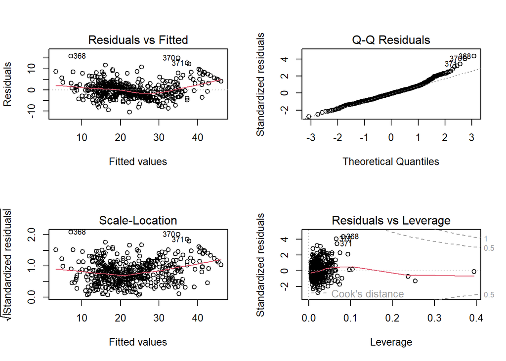

```r
par(mfrow=c(2,2))
plot(lm.fit.new)
```

```r
par(mfrow=c(1,1))
```

The removal of outliers and high-leverage points has improved the residual plots as well as the R-squared statistics. We also note that the value of the residual standard error has decreased, as expected after the removal of the outliers.